# SMART-Seq2 mRNA-Seq of blastocysts from wt M PWD x F FVB OgtT931A-het or OgtT931del-het/wt - DE analysis

Sara Formichetti

EMBL Rome  
sara.formichetti@embl.it

January 19th, 2024

# 1 Ogt expression

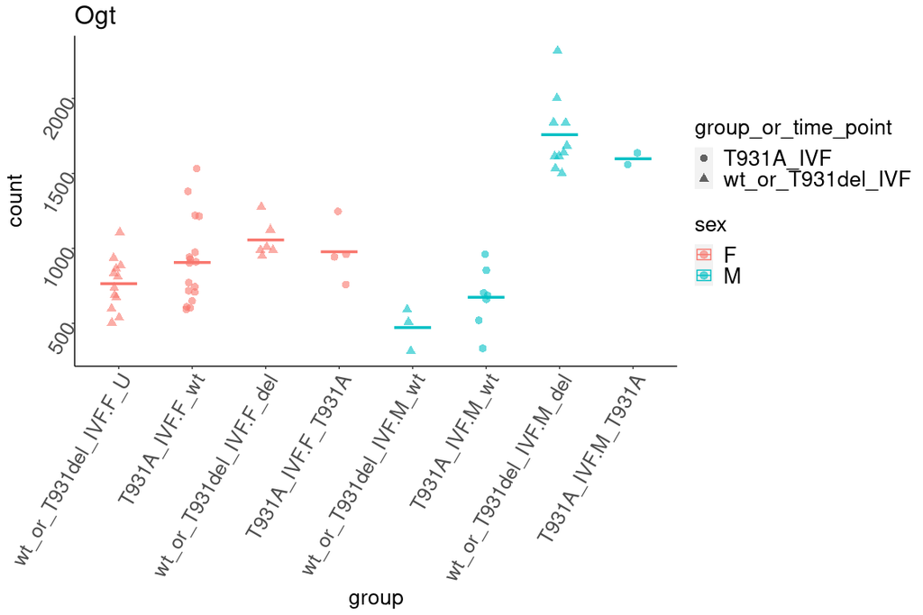

In good agreement with PCA separation between embryos’ genotypes found only in male samples, Ogt “compensatory change” is mostly visible in male samples.

# 2 DESeq2 - between “IVF drops”, to investigate batch effect, separately for the two sexes

Number of replicates (single embryos) is too little for the males, females are more informative.

## 2.1 MA-plots

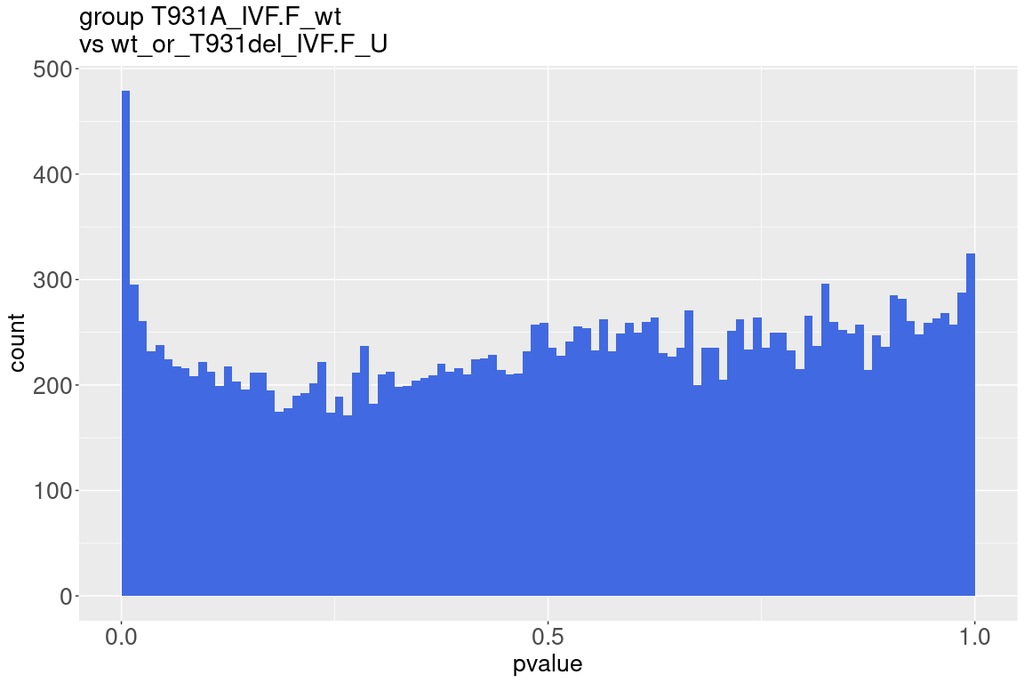

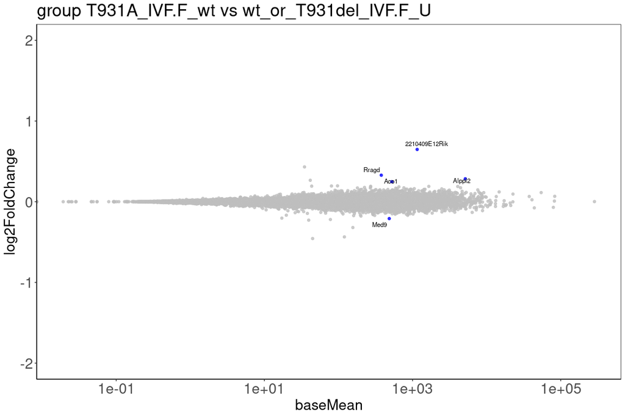

## 2.2 Conclusion

Only a few DEGs due to batch effect, hence I can proceed comparing male OgtT931del embryos and male wt embryos, even if most wt embryos come from the pair of OgtT931A-het mothers.

# 3 DESeq2 - males only, OgtT931del-hemizygous vs wt

- I exclude the two embryos with the point mutations because they are too few.
- I pool the wt embryos coming from the two IVF drops.
- I include the IVF drop as batch effect in DESeq formula.

## 3.1 MA-plots

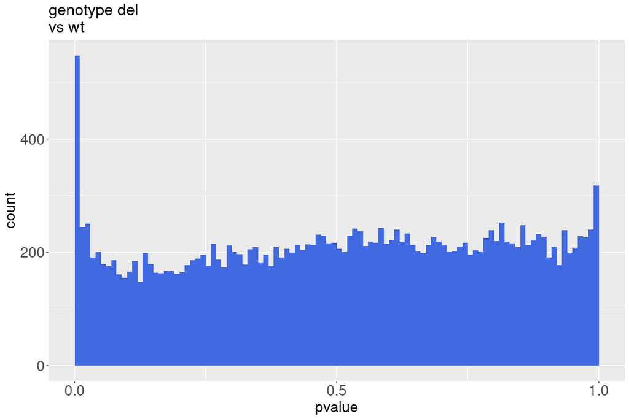

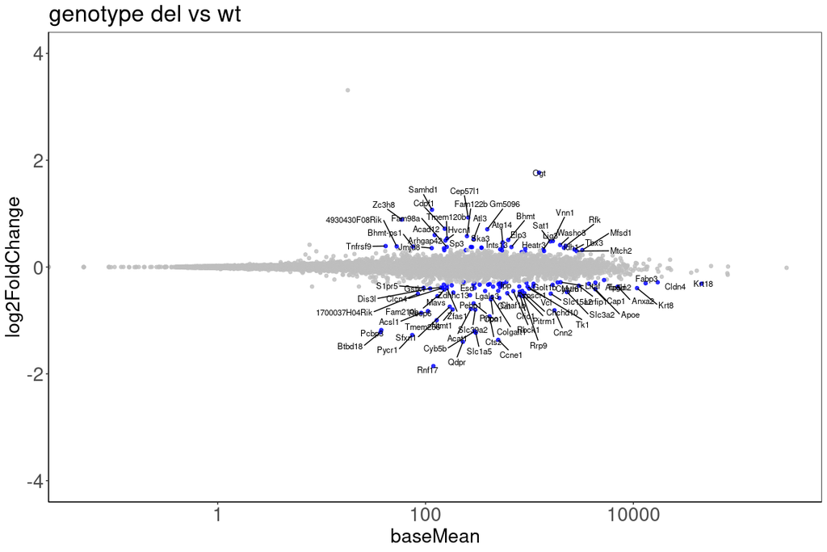

## 3.2 DEGs counts

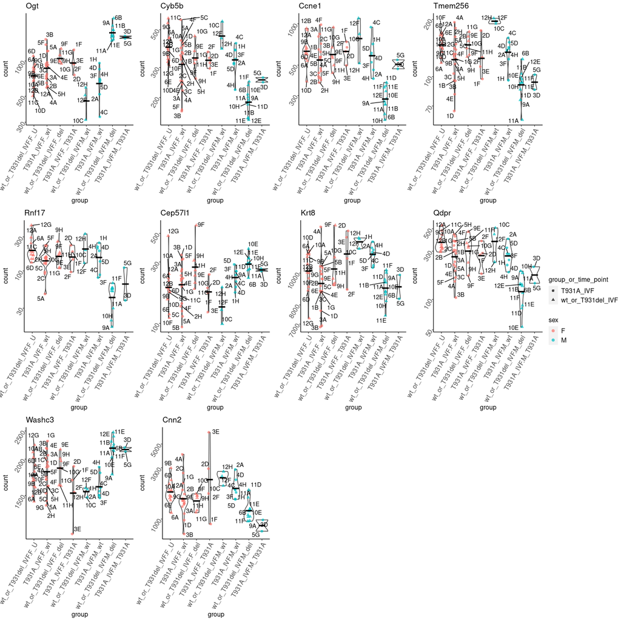

- In most of the cases, the same trend observed in T931del embryos is observed as well in T931A embryos, supporting the differential expression being due to Ogt disruption.
- For most of the genes plotted, counts for wt coming from T931A mothers are lower than for wt coming from del/wt mothers, indicating either an effect of mothers’ genotype or of the different IVF drop (i.e. experimental batch effect). However, this effect can only dampen the difference between T931del and wt, hence it will not create false positive DEGs but more the opposite.

# 4 Gene Set Enrichment Test

- I remove Ogt from the input list of genes.
- I also perform the test on DESeq result for female wt embryos when comparing IVF drosp (T931A mothers vs the other pair), in order to compare it with the result obtained for male embryos T931del vs wt.

Females wt - IVF drop - Biological Process GO

|  | ID | Description | setSize | enrichmentScore | NES | pvalue | p.adjust | qvalues | rank | leading_edge | core_enrichment |
| --- | --- | --- | --- | --- | --- | --- | --- | --- | --- | --- | --- |
| GO:0006119 | GO:0006119 | oxidative phosphorylation | 96 | -0.6251693 | -2.400215 | 0.0000000 | 0.0000001 | 0.0000001 | 1749 | tags=45%, list=15%, signal=38% | Atp5k/Atp5a1/Cdk1/Ndufs7/Mtch2/Fxn/Cyc1/Ndufb6/Atp5d/Uqcrc1/…… |
| GO:0046034 | GO:0046034 | ATP metabolic process | 198 | -0.5121786 | -2.164227 | 0.0000000 | 0.0000001 | 0.0000001 | 1769 | tags=35%, list=15%, signal=30% | Adpgk/Atp5k/Ddit4/Atp5a1/Cdk1/Ndufs7/Zbtb20/Mtch2/Fxn/Cyc1/N…… |
| GO:0016197 | GO:0016197 | endosomal transport | 193 | 0.4637825 | 1.823737 | 0.0000009 | 0.0002529 | 0.0002286 | 2466 | tags=32%, list=21%, signal=25% | Actn2/Usp7/Inpp5f/Vps54/Vps52/Dennd1b/Snx3/Eps15/Cmtm6/Washc…… |
| GO:0000028 | GO:0000028 | ribosomal small subunit assembly | 19 | -0.8015117 | -2.182940 | 0.0000022 | 0.0005764 | 0.0005211 | 796 | tags=42%, list=7%, signal=39% | Rps25/Rps5/Rps27/Rpsa/Rps14/Rps15/Rps28/Rpl38 |
| GO:0007033 | GO:0007033 | vacuole organization | 151 | 0.4891468 | 1.878518 | 0.0000024 | 0.0005930 | 0.0005361 | 2059 | tags=34%, list=17%, signal=28% | Tmem41b/Grn/Man2a1/Tpp1/Map1lc3b/Vps11/Gaa/Pip4k2c/Gabarapl2…… |
| GO:0043161 | GO:0043161 | proteasome-mediated ubiquitin-dependent protein catabolic process | 348 | 0.3923502 | 1.638494 | 0.0000025 | 0.0005960 | 0.0005388 | 2768 | tags=35%, list=23%, signal=28% | Usp7/Rmnd5a/Psmd1/Trim13/Plk2/Hsp90ab1/Faf2/Mdm2/Btrc/Plaa/E…… |
| GO:0035970 | GO:0035970 | peptidyl-threonine dephosphorylation | 11 | 0.8710935 | 1.999656 | 0.0000204 | 0.0040533 | 0.0036643 | 307 | tags=45%, list=3%, signal=44% | Pdp2/Ppm1a/Dusp18/Ppm1b/Dusp10 |
| GO:0002181 | GO:0002181 | cytoplasmic translation | 90 | -0.4910923 | -1.857607 | 0.0000529 | 0.0093757 | 0.0084758 | 1423 | tags=33%, list=12%, signal=30% | Nck1/Rpl8/Rpl11/Rps23/Gspt2/Rpl39/Eif3d/Eif3i/Lin28a/Rpl29/Rps21/Rpl18/Rpl18a/Rpl32/Rpl26/Rpsa/Rpl35a/Rpl36a/Rpl31/Rpl22/Rplp2/Rpl30/Rpl36al/Rplp1/Tma7/Rps28/Rpl36/Rpl38/Rpl41/Dph5 |
| GO:0072583 | GO:0072583 | clathrin-dependent endocytosis | 34 | 0.6479295 | 1.935631 | 0.0000716 | 0.0118521 | 0.0107144 | 1640 | tags=38%, list=14%, signal=33% | Inpp5f/Btbd8/Fcho2/Picalm/Cltc/Canx/Scyl2/Ap2b1/Neu3/Itsn2/Aak1/Ap2a2/Fnbp1l |
| GO:0021953 | GO:0021953 | central nervous system neuron differentiation | 87 | 0.5093965 | 1.809668 | 0.0000784 | 0.0125573 | 0.0113520 | 2012 | tags=34%, list=17%, signal=29% | Hsp90aa1/Nin/Gigyf2/Hsp90ab1/Pten/Ephb6/Btg2/Arhgap35/Ubb/Atp2b2/Celf1/Scyl3/Gba2/Scyl2/Atg7/Hes1/Chd5/Pals1/Ndel1/Psap/Epha4/Ift172/Psen1/Dync2h1/Ttll1/Tfap2c/Rac1/Satb2/Ulk1/Herc1 |
| GO:0019827 | GO:0019827 | stem cell population maintenance | 135 | 0.4523856 | 1.703800 | 0.0000998 | 0.0152511 | 0.0137872 | 2290 | tags=30%, list=19%, signal=24% | Dppa2/Ctr9/Cnot2/Tut4/Med17/Mtf2/Smc5/Tbx3/Cnot3/Foxo3/Sct/P…… |
| GO:0006914 | GO:0006914 | autophagy | 346 | 0.3679729 | 1.536740 | 0.0001044 | 0.0152511 | 0.0137872 | 2059 | tags=26%, list=17%, signal=22% | Rragd/Tmem41b/Trim13/Ctsa/Map1lc3b/Plk2/Calcoco2/Rragc/Vps11…… |
| GO:0061919 | GO:0061919 | process utilizing autophagic mechanism | 346 | 0.3679729 | 1.536740 | 0.0001044 | 0.0152511 | 0.0137872 | 2059 | tags=26%, list=17%, signal=22% | Rragd/Tmem41b/Trim13/Ctsa/Map1lc3b/Plk2/Calcoco2/Rragc/Vps11…… |
| GO:0021543 | GO:0021543 | pallium development | 85 | 0.5128635 | 1.814511 | 0.0001250 | 0.0172350 | 0.0155806 | 1892 | tags=36%, list=16%, signal=31% | Cep120/Srgap2/Pten/Btg2/Mboat7/Cul5/Gsk3b/Sct/Uba6/Syne2/Tsc1/Tacc1/Rnf7/Celf1/Xrcc1/Bax/Atg7/Pals1/Ndel1/Bbs2/Ccdc85c/Lrp6/Aspm/Sun1/Mcph1/Psen1/Tacc2/Ctnnb1/Tfap2c/Rac1/Grin1 |
| GO:0045930 | GO:0045930 | negative regulation of mitotic cell cycle | 178 | 0.4186179 | 1.635238 | 0.0001397 | 0.0187442 | 0.0169450 | 2103 | tags=29%, list=18%, signal=24% | Btg1/Ppp1r10/Map3k20/Gigyf2/Bub1b/Mdm2/Pten/Rbm38/Taok2/Ccng…… |
| GO:0006403 | GO:0006403 | RNA localization | 154 | 0.4344461 | 1.671216 | 0.0001970 | 0.0222267 | 0.0200932 | 2320 | tags=29%, list=20%, signal=23% | Ddx19b/Mcm3ap/Iws1/Ckap5/Cct2/Igf2bp2/Hnrnpa3/Lrpprc/Kif5c/A…… |
| GO:0015985 | GO:0015985 | energy coupled proton transport, down electrochemical gradient | 19 | -0.7288365 | -1.985007 | 0.0002266 | 0.0244606 | 0.0221127 | 2283 | tags=74%, list=19%, signal=60% | Dnajc30/Atp5c1/Atp5j/Atp5k/Atp5a1/Atp5d/Stoml2/Atp5o/Atp5g3/Atp5g1/Atp5l/Atp5e/Atp5g2/Atp5j2 |
| GO:0015986 | GO:0015986 | ATP synthesis coupled proton transport | 19 | -0.7288365 | -1.985007 | 0.0002266 | 0.0244606 | 0.0221127 | 2283 | tags=74%, list=19%, signal=60% | Dnajc30/Atp5c1/Atp5j/Atp5k/Atp5a1/Atp5d/Stoml2/Atp5o/Atp5g3/Atp5g1/Atp5l/Atp5e/Atp5g2/Atp5j2 |
| GO:1903311 | GO:1903311 | regulation of mRNA metabolic process | 235 | 0.3918987 | 1.564946 | 0.0002626 | 0.0263246 | 0.0237977 | 2505 | tags=31%, list=21%, signal=25% | Wtap/Iws1/Ctr9/Cnot2/Gigyf2/Tut4/Papola/Sltm/Rbm38/Pan3/Hnrn…… |
| GO:0061615 | GO:0061615 | glycolytic process through fructose-6-phosphate | 15 | -0.7741499 | -1.985178 | 0.0002627 | 0.0263246 | 0.0237977 | 1177 | tags=47%, list=10%, signal=42% | Gale/Eno2/Pfkp/Pfkl/Eno1/Eno1b/Aldoa |
| GO:0010564 | GO:0010564 | regulation of cell cycle process | 499 | 0.3310902 | 1.420550 | 0.0002642 | 0.0263246 | 0.0237977 | 2130 | tags=24%, list=18%, signal=21% | Tpx2/Cep120/Ptpn6/Tert/Ppp1r10/Map3k20/Gigyf2/Psrc1/Plk2/Bub…… |
| GO:1990542 | GO:1990542 | mitochondrial transmembrane transport | 76 | -0.4915927 | -1.815125 | 0.0002771 | 0.0263246 | 0.0237977 | 1963 | tags=33%, list=17%, signal=28% | Atp5j/Tst/Mrpl18/Slc25a1/Atp5k/Chchd4/Slc25a29/Atp5a1/Grpel1/Atp5d/Romo1/Stoml2/Timm21/Timm50/Slc25a4/Atp5o/Slc25a22/Pam16/Sfxn1/Vdac1/Atp5e/Dnajc19/Tomm7/Atp5j2/Smdt1 |
| GO:0051028 | GO:0051028 | mRNA transport | 104 | 0.4667973 | 1.715014 | 0.0002810 | 0.0263246 | 0.0237977 | 2320 | tags=30%, list=20%, signal=24% | Ddx19b/Mcm3ap/Iws1/Igf2bp2/Hnrnpa3/Lrpprc/Kif5c/Aaas/Fmr1/Nup54/Ranbp2/Akap8l/Igf2bp3/Nup98/Thoc2/Chtop/Setd2/Nupl2/Tpr/Bcl2l2/Nup188/Alyref/Nup160/Ncbp1/Dhx9/Nsun2/Gle1/Supt6/Hhex/Hnrnpa2b1/Ythdc1 |
| GO:0021955 | GO:0021955 | central nervous system neuron axonogenesis | 22 | 0.7128359 | 1.929966 | 0.0003038 | 0.0279339 | 0.0252525 | 1226 | tags=41%, list=10%, signal=37% | Hsp90aa1/Nin/Hsp90ab1/Pten/Ephb6/Arhgap35/Atg7/Ndel1/Epha4 |
| GO:0051656 | GO:0051656 | establishment of organelle localization | 299 | 0.3606349 | 1.482872 | 0.0003918 | 0.0342737 | 0.0309838 | 2852 | tags=37%, list=24%, signal=29% | Cep120/Psrc1/Gpsm2/Pibf1/Ubb/Cenpe/Fer/Ttl/Lamp1/Actr10/Kif5…… |
| GO:0042044 | GO:0042044 | fluid transport | 11 | 0.8181965 | 1.878228 | 0.0004289 | 0.0367149 | 0.0331908 | 260 | tags=27%, list=2%, signal=27% | Aqp9/Aqp3/Slc4a11 |
| GO:0046466 | GO:0046466 | membrane lipid catabolic process | 24 | 0.6848760 | 1.879660 | 0.0004377 | 0.0368320 | 0.0332966 | 1964 | tags=58%, list=17%, signal=49% | Smpd1/Acer3/Hexa/Pnliprp2/Gba2/Sgpl1/Neu1/Neu3/Psap/Gm2a/Gba/Gla/Hexb/Acer2 |
| GO:0010972 | GO:0010972 | negative regulation of G2/M transition of mitotic cell cycle | 54 | 0.5454684 | 1.779125 | 0.0004932 | 0.0398347 | 0.0360111 | 1062 | tags=28%, list=9%, signal=25% | Taok2/Ccng1/Nabp1/Cdkn1a/Topbp1/Usp47/Rad21/Mbd4/Vps4a/Taok1/Atm/Ticrr/Ints3/Donson/Rad17 |
| GO:0002694 | GO:0002694 | regulation of leukocyte activation | 270 | 0.3698088 | 1.500953 | 0.0005311 | 0.0418547 | 0.0378372 | 1674 | tags=21%, list=14%, signal=19% | Inpp5d/Pik3r6/Hsp90aa1/Timd2/Grn/Ptpn6/Ephb6/Efnb2/Zc3h8/Dusp10/Sdc4/Pibf1/Cdkn1a/Fer/Lamp1/Sh2b3/Gata1/Aplf/Erbb2/Flot2/Stat6/Cd59a/Ap3b1/Peli1/H2-Ab1/Lgals8/Paxip1/Atm/Gpam/Csk/Hes1/Bcl10/Pkn1/Tex10… |
| GO:0009896 | GO:0009896 | positive regulation of catabolic process | 374 | 0.3388073 | 1.423420 | 0.0006704 | 0.0493910 | 0.0446501 | 2028 | tags=24%, list=17%, signal=21% | Hsp90aa1/Cnot2/Gigyf2/Tut4/Trim13/Plk2/Calcoco2/Mdm2/Vps11/P…… |
| GO:0032259 | GO:0032259 | methylation | 293 | 0.3664916 | 1.503605 | 0.0006741 | 0.0493910 | 0.0446501 | 2485 | tags=28%, list=21%, signal=23% | Btg1/Wtap/Prdm4/Ezh1/Dppa2/Iws1/Kdm1b/Ctr9/Dppa3/Mtf2/Dalrd3…… |
| GO:2001252 | GO:2001252 | positive regulation of chromosome organization | 71 | 0.5012589 | 1.725074 | 0.0006864 | 0.0493910 | 0.0446501 | 2673 | tags=39%, list=23%, signal=31% | Ppp1r10/Cct2/Smc5/Rad50/Acd/Sgo2a/Rad21/Atf7ip/Slx4/Nek2/Nsmce2/Atm/Slf2/Hmbox1/Tpr/Ctnnb1/Tnks2/Setdb1/Mad1l1/Macroh2a1/Hnrnpa2b1/Dhx36/Morc2a/Pnkp/Tasor/Mapk1/Lig4/Pot1a |

Females wt - IVF drop - Molecular Function GO

|  | ID | Description | setSize | enrichmentScore | NES | pvalue | p.adjust | qvalues | rank | leading_edge | core_enrichment |
| --- | --- | --- | --- | --- | --- | --- | --- | --- | --- | --- | --- |
| GO:0140657 | GO:0140657 | ATP-dependent activity | 415 | 0.4030040 | 1.721245 | 0.0000001 | 0.0000153 | 0.0000136 | 2531 | tags=33%, list=21%, signal=26% | Ddx19b/Hsp90aa1/Slc4a2/Dhx16/Cct2/Dhx8/Msh6/Hsp90ab1/Ddx52/H…… |
| GO:0009055 | GO:0009055 | electron transfer activity | 53 | -0.6539937 | -2.209327 | 0.0000002 | 0.0000348 | 0.0000308 | 1171 | tags=38%, list=10%, signal=34% | Ndufv1/Ndufs4/Etfb/Ndufc2/Ndufv2/Ndufa10/Cox5a/Cyct/Cox7a2/Cox7b/Ndufa2/Sdhb/Cox4i1/Cox8a/Ndufb8/Uqcr11/Uqcrh/Uqcrq/Cox6a1/Ndufb7 |
| GO:0015453 | GO:0015453 | oxidoreduction-driven active transmembrane transporter activity | 40 | -0.6795724 | -2.168612 | 0.0000020 | 0.0003509 | 0.0003112 | 1588 | tags=48%, list=13%, signal=41% | Ndufs7/Cyc1/Ndufv1/Ndufs4/Ndufc2/Ndufv2/Ndufa10/Cox5a/Cox7a2/Cox7b/Ndufa2/Cox4i1/Cox8a/Ndufb8/Uqcr11/Uqcrh/Uqcrq/Cox6a1/Ndufb7 |
| GO:0008017 | GO:0008017 | microtubule binding | 196 | 0.4532157 | 1.783794 | 0.0000039 | 0.0005698 | 0.0005052 | 2073 | tags=30%, list=18%, signal=25% | Tpx2/Gas2/Ckap5/Nin/Map1lc3b/Psrc1/Gas2l1/Tubgcp6/Gtse1/Kif2…… |
| GO:0140030 | GO:0140030 | modification-dependent protein binding | 140 | 0.4562231 | 1.738941 | 0.0000786 | 0.0076362 | 0.0067708 | 2808 | tags=36%, list=24%, signal=28% | Mbtd1/Ptpn6/Dppa3/Mtf2/Msh6/Suz12/Eps15/Ubqln1/Brd7/Msl3/Vcp…… |
| GO:0003954 | GO:0003954 | NADH dehydrogenase activity | 23 | -0.7190446 | -2.038957 | 0.0000791 | 0.0076362 | 0.0067708 | 2337 | tags=61%, list=20%, signal=49% | Ndufa13/Ndufs3/Ndufs8/Ndufs7/Enox1/Ndufb1/Ndufv1/Ndufs4/Ndufc2/Ndufv2/Ndufa10/Ndufa2/Ndufb8/Ndufb7 |
| GO:0015144 | GO:0015144 | carbohydrate transmembrane transporter activity | 19 | 0.7541390 | 1.982726 | 0.0001061 | 0.0092219 | 0.0081768 | 390 | tags=32%, list=3%, signal=31% | Aqp9/Aqp3/Slc45a4/Tmem144/Slc2a3/Slc2a8 |
| GO:0061659 | GO:0061659 | ubiquitin-like protein ligase activity | 237 | 0.3914916 | 1.575523 | 0.0002833 | 0.0138837 | 0.0123105 | 2450 | tags=31%, list=21%, signal=25% | Rnf111/Rmnd5a/Trim13/Mdm2/Btrc/Vps11/Irf2bpl/Wwp2/Trim32/Ube…… |
| GO:0015078 | GO:0015078 | proton transmembrane transporter activity | 72 | -0.4735584 | -1.718961 | 0.0004768 | 0.0172954 | 0.0153355 | 914 | tags=32%, list=8%, signal=30% | Cyc1/Atp5d/Slc36a1/Atp6v1g1/Slc9b1/Slc25a4/Atp5o/Atp5g3/Cox5a/Atp5g1/Atp5l/Atp5e/Atp5g2/Cox7a2/Cox7b/Clcn5/Cox4i1/Cox8a/Uqcr11/Uqcrh/Atp5j2/Uqcrq/Cox6a1 |
| GO:0004364 | GO:0004364 | glutathione transferase activity | 18 | -0.7296581 | -1.956245 | 0.0004777 | 0.0172954 | 0.0153355 | 1653 | tags=50%, list=14%, signal=43% | Gstm1/Gstp2/Gstz1/Mgst3/Gstm2/Gsta4/Gsto1/Gstp1/Ltc4s |
| GO:0051020 | GO:0051020 | GTPase binding | 263 | 0.3666878 | 1.492861 | 0.0005549 | 0.0180210 | 0.0159789 | 2046 | tags=25%, list=17%, signal=22% | Rragd/Lztr1/Hsp90aa1/Rab11fip1/Dennd1b/Usp6nl/Srgap2/Rragc/D…… |
| GO:0032183 | GO:0032183 | SUMO binding | 13 | 0.7704776 | 1.835924 | 0.0011288 | 0.0338243 | 0.0299914 | 601 | tags=23%, list=5%, signal=22% | Rnf111/Usp25/Uspl1 |
| GO:0003729 | GO:0003729 | mRNA binding | 262 | 0.3642753 | 1.482852 | 0.0014417 | 0.0391521 | 0.0347155 | 3002 | tags=38%, list=25%, signal=29% | Aco1/Slc4a1ap/Igf2bp2/Ilf3/Eif3a/Rbm38/Hnrnpa0/Sf3b1/Hnrnpa3…… |
| GO:0055105 | GO:0055105 | ubiquitin-protein transferase inhibitor activity | 10 | -0.7843206 | -1.813701 | 0.0018394 | 0.0456692 | 0.0404940 | 2165 | tags=80%, list=18%, signal=65% | Fbxo5/Rpl37/Glmn/Rpl11/Rpl23/Rps20/Rpl37rt/Rps15 |
| GO:0016846 | GO:0016846 | carbon-sulfur lyase activity | 10 | -0.7811516 | -1.806373 | 0.0020324 | 0.0490590 | 0.0434997 | 999 | tags=50%, list=8%, signal=46% | Cth/Mgst3/Cenpv/Glo1/Ltc4s |
| GO:0031625 | GO:0031625 | ubiquitin protein ligase binding | 245 | 0.3562963 | 1.434655 | 0.0022928 | 0.0498105 | 0.0441661 | 1356 | tags=20%, list=11%, signal=18% | Usp7/Traf4/Hsp90aa1/Psmd1/Map1lc3b/Cct2/Usp25/Hsp90ab1/Faf2/Mdm2/Erlin2/Hspa5/Gabarapl2/Lrpprc/Cdkn1a/Ubb/Ubxn7/Hspa8/Cul5/Gsk3b/Aurka/Vcp/Ubc/Erbb2/Chek2/Calr/Jak1/Rnf20/Derl1/Washc1/Pik3r1/H2-Ab1/Sp… |

Females wt - IVF drop - Cellular Component GO

|  | ID | Description | setSize | enrichmentScore | NES | pvalue | p.adjust | qvalues | rank | leading_edge | core_enrichment |
| --- | --- | --- | --- | --- | --- | --- | --- | --- | --- | --- | --- |
| GO:1902495 | GO:1902495 | transmembrane transporter complex | 140 | -0.6017567 | -2.433230 | 0.0000000 | 0.0000000 | 0.0000000 | 1408 | tags=35%, list=12%, signal=31% | Cyc1/Ndufb6/Scnn1a/Ndufab1/Ndufs5/Clcnkb/Uqcrc1/Uqcrb/Ndufv1…… |
| GO:1990351 | GO:1990351 | transporter complex | 151 | -0.5923476 | -2.411514 | 0.0000000 | 0.0000000 | 0.0000000 | 1408 | tags=34%, list=12%, signal=31% | Cyc1/Ndufb6/Scnn1a/Ndufab1/Ndufs5/Clcnkb/Uqcrc1/Uqcrb/Ndufv1…… |
| GO:0070069 | GO:0070069 | cytochrome complex | 24 | -0.7346632 | -2.115293 | 0.0000370 | 0.0009276 | 0.0007662 | 1408 | tags=58%, list=12%, signal=51% | Cyc1/Uqcrc1/Uqcrb/AA467197/Uqcc3/Cox5a/Cox7b/Cox4i1/Cox8a/Uqcrh/Uqcrq/Cox6a1/Uqcr10/Cox6b1 |
| GO:0045259 | GO:0045259 | proton-transporting ATP synthase complex | 18 | -0.7661042 | -2.086372 | 0.0000527 | 0.0012704 | 0.0010493 | 2283 | tags=78%, list=19%, signal=63% | Atp5c1/Atp5j/Atp5k/Atp5a1/Atp5d/Atp5md/Atp5o/Atp5g3/Atp5g1/Atp5l/Atp5e/Atp5g2/Atp5mpl/Atp5j2 |
| GO:0005874 | GO:0005874 | microtubule | 327 | 0.3711245 | 1.535713 | 0.0001439 | 0.0031112 | 0.0025698 | 2073 | tags=26%, list=18%, signal=22% | Tpx2/Ckap5/Nin/Cep170b/Map1lc3b/Cct2/Psrc1/Eif3a/Tuba4a/Gas2…… |
| GO:0016607 | GO:0016607 | nuclear speck | 288 | 0.3849812 | 1.578359 | 0.0001670 | 0.0033772 | 0.0027895 | 3093 | tags=36%, list=26%, signal=27% | Wtap/Tcf12/Tert/Dennd1b/Smc5/Surf2/Thrap3/Sf3b1/Dusp10/Haus6…… |
| GO:0005687 | GO:0005687 | U4 snRNP | 10 | -0.8521230 | -1.924586 | 0.0002222 | 0.0043544 | 0.0035967 | 302 | tags=70%, list=3%, signal=68% | Snrpb/Prpf31/Snrpe/Snrpf/Snrpd1/Snrpd2/Snrpg |
| GO:0000151 | GO:0000151 | ubiquitin ligase complex | 266 | 0.3685806 | 1.503078 | 0.0004407 | 0.0065792 | 0.0054343 | 2753 | tags=34%, list=23%, signal=27% | Elobl/Lztr1/Pramel6/Rmnd5a/Btrc/Pramel48/Fbxl20/Anapc10/Ube4…… |
| GO:0034709 | GO:0034709 | methylosome | 12 | -0.8103844 | -1.958195 | 0.0005139 | 0.0073232 | 0.0060488 | 761 | tags=50%, list=6%, signal=47% | Prmt1/Snrpe/Snrpf/Snrpd1/Snrpd2/Snrpg |
| GO:0072686 | GO:0072686 | mitotic spindle | 138 | 0.4345826 | 1.632251 | 0.0006458 | 0.0089978 | 0.0074321 | 2224 | tags=34%, list=19%, signal=28% | Tpx2/Nin/Tfdp2/Gpsm2/Kif20b/Epb41/Racgap1/Cenpe/Haus6/Aurka/…… |
| GO:0034719 | GO:0034719 | SMN-Sm protein complex | 17 | -0.7164506 | -1.910106 | 0.0007842 | 0.0100341 | 0.0082881 | 302 | tags=35%, list=3%, signal=34% | Snrpe/Snrpf/Snrpd1/Gemin8/Snrpd2/Snrpg |
| GO:0005838 | GO:0005838 | proteasome regulatory particle | 23 | 0.6460276 | 1.790513 | 0.0017056 | 0.0201775 | 0.0166663 | 2080 | tags=61%, list=18%, signal=50% | Psmd1/Psmd11/Psmd7/Psmd8/Adrm1/Psmd12/Gm9774/Psmd5/Psmc6/Psmc2/Psmd3/Psmc4/Psmd2/Psmd14 |
| GO:1990124 | GO:1990124 | messenger ribonucleoprotein complex | 13 | 0.7308810 | 1.731958 | 0.0029085 | 0.0303305 | 0.0250526 | 1410 | tags=38%, list=12%, signal=34% | Hnrnpa3/Hspa8/Lsm14a/Fmr1/Stau2 |
| GO:0031519 | GO:0031519 | PcG protein complex | 42 | 0.5444419 | 1.723330 | 0.0033975 | 0.0341606 | 0.0282163 | 1305 | tags=31%, list=11%, signal=28% | Ezh1/Ubap2l/Mtf2/Suz12/Aebp2/Zfp143/Pcgf3/Asxl2/Asxl1/Cbx2/Yy1/Csnk2a1/Rbbp7 |
| GO:0030139 | GO:0030139 | endocytic vesicle | 143 | 0.3881608 | 1.467560 | 0.0039280 | 0.0384820 | 0.0317857 | 1864 | tags=26%, list=16%, signal=22% | Cdc42ep4/Inpp5f/Igf2r/Zdhhc5/Srgap2/Vps11/Snx3/Ftl1/Eps15/La…… |
| GO:0016234 | GO:0016234 | inclusion body | 57 | 0.4941345 | 1.645331 | 0.0043697 | 0.0415119 | 0.0342883 | 1730 | tags=40%, list=15%, signal=35% | Hsp90ab1/Eps15/Rad50/Ubqln1/Eef2/Picalm/Ranbp2/Nup98/Atxn1/Rangap1/Xrn2/Psap/Keap1/Arih1/Atxn3/Fbxo7/Psmc6/Tpr/Psen1/Bcl2l2/Dnajb2/Dvl2/Psmc4 |
| GO:0005789 | GO:0005789 | endoplasmic reticulum membrane | 427 | 0.3102577 | 1.316501 | 0.0058608 | 0.0496784 | 0.0410338 | 2197 | tags=25%, list=19%, signal=21% | Tmem41b/Elovl7/Trim13/Faf2/Pemt/Tmem159/Soat1/Acer3/Lbr/Rft1…… |
| GO:0012506 | GO:0012506 | vesicle membrane | 384 | 0.3215591 | 1.350857 | 0.0058632 | 0.0496784 | 0.0410338 | 2031 | tags=24%, list=17%, signal=21% | Lztr1/Igf2r/Syngr1/Rap2b/Snx3/Slc4a11/Vps37a/Tmed2/Eps15/Cmt…… |

Males - del vs wt - Biological Process GO

|  | ID | Description | setSize | enrichmentScore | NES | pvalue | p.adjust | qvalues | rank | leading_edge | core_enrichment |
| --- | --- | --- | --- | --- | --- | --- | --- | --- | --- | --- | --- |
| GO:0048385 | GO:0048385 | regulation of retinoic acid receptor signaling pathway | 10 | 0.9042942 | 2.009274 | 1.07e-05 | 0.016614 | 0.0158341 | 785 | tags=50%, list=7%, signal=47% | Ezh2/Calr/Snw1/Tgif1/Cnot1 |
| GO:0006091 | GO:0006091 | generation of precursor metabolites and energy | 311 | -0.4128342 | -1.667397 | 1.12e-05 | 0.016614 | 0.0158341 | 1613 | tags=27%, list=14%, signal=24% | Ndor1/Slc25a22/Atpsckmt/Actn3/G6pdx/Adsl/Abcd1/Oxct1/Hkdc1/D…… |
| GO:0019646 | GO:0019646 | aerobic electron transport chain | 48 | -0.6646079 | -2.064439 | 1.24e-05 | 0.016614 | 0.0158341 | 2569 | tags=52%, list=22%, signal=41% | Cox5a/Sdhd/Ndufs6/Coq9/Cox5b/Uqcc3/Ndufb6/Park7/Ndufb8/Sdha/Sdhc/Cox7c/Ndufa7/Cyc1/Ndufs3/Cox6a1/Ndufb9/Uqcrc1/Uqcr10/Cyct/Cox4i1/Ndufs7/Ndufv1/Ndufa10/Uqcrq |
| GO:0006520 | GO:0006520 | cellular amino acid metabolic process | 179 | -0.4642496 | -1.760657 | 1.37e-05 | 0.016614 | 0.0158341 | 1273 | tags=25%, list=11%, signal=23% | Hars2/Apip/Hsd17b10/Gcsh/Wars/Lars/Gatb/Enoph1/Tars/Sdsl/Tst…… |
| GO:0006397 | GO:0006397 | mRNA processing | 406 | 0.3662471 | 1.533815 | 1.68e-05 | 0.016614 | 0.0158341 | 2493 | tags=33%, list=21%, signal=27% | Rbmx/Ddx17/Srpk1/Zmat5/Ncl/Nup98/Dhx9/Cdk9/Hnrnpa2b1/Coil/Us…… |

Males - del vs wt - Molecular Function GO

|  | ID | Description | setSize | enrichmentScore | NES | pvalue | p.adjust | qvalues | rank | leading_edge | core_enrichment |
| --- | --- | --- | --- | --- | --- | --- | --- | --- | --- | --- | --- |
| GO:0009055 | GO:0009055 | electron transfer activity | 54 | -0.6835156 | -2.172262 | 0.0000018 | 0.0007781 | 0.0006573 | 1831 | tags=52%, list=15%, signal=44% | Cox7b/Ndufb8/Ndor1/Cox7a2l/Ndufa13/Ndufs4/Sdha/Sdhc/Cyba/Aifm2/Uqcr11/Cox7c/Ndufa7/Sdhb/Cyc1/Cox7a2/Ndufa2/Etfb/Ndufs3/Cox6a1/Cox8a/Cyct/Uqcrfs1/Cox4i1/Ndufs7/Ndufv1/Ndufa10/Uqcrq |
| GO:0015453 | GO:0015453 | oxidoreduction-driven active transmembrane transporter activity | 41 | -0.7152670 | -2.129358 | 0.0000018 | 0.0007781 | 0.0006573 | 1831 | tags=49%, list=15%, signal=41% | Cox7b/Ndufb8/Cox7a2l/Ndufa13/Ndufs4/Uqcr11/Cox7c/Ndufa7/Cyc1/Cox7a2/Ndufa2/Ndufs3/Cox6a1/Cox8a/Uqcrfs1/Cox4i1/Ndufs7/Ndufv1/Ndufa10/Uqcrq |
| GO:0003682 | GO:0003682 | chromatin binding | 478 | 0.3680059 | 1.569298 | 0.0000040 | 0.0009374 | 0.0007919 | 1910 | tags=25%, list=16%, signal=22% | Sp3/Msh6/Rbmx/Phf8/Dppa4/Mbtd1/Parg/Rad21/Nup98/Sbno1/Dhx9/U…… |
| GO:0004386 | GO:0004386 | helicase activity | 138 | 0.4968729 | 1.863212 | 0.0000043 | 0.0009374 | 0.0007919 | 1459 | tags=29%, list=12%, signal=26% | Ercc6l/Dna2/Ddx17/Dhx9/Ddx11/Chd8/Helq/Ddx18/Ddx59/Ddx46/Ddx…… |
| GO:0008080 | GO:0008080 | N-acetyltransferase activity | 59 | 0.6166139 | 2.056494 | 0.0000103 | 0.0017848 | 0.0015077 | 1692 | tags=42%, list=14%, signal=37% | Sat1/Elp3/Nat1/Gtf2b/Nat2/Ncoa3/Mettl8/Gnpnat1/Kat14/Cdyl/Naa16/Kat6a/Nat8f1/Taf1/Naa10/Naa11/Med24/Ep300/Kat2b/Hat1/Atf2/Hgsnat/Brca2/Naa50/Nat10 |
| GO:0140657 | GO:0140657 | ATP-dependent activity | 414 | 0.3775215 | 1.587496 | 0.0000137 | 0.0017988 | 0.0015196 | 2196 | tags=32%, list=19%, signal=27% | Ercc6l/Dna2/Msh6/Dnah10/Clpx/Ddx17/Btaf1/Dhx9/Ddx11/Chd8/Abc…… |
| GO:0005198 | GO:0005198 | structural molecule activity | 343 | -0.3872340 | -1.583174 | 0.0000236 | 0.0022732 | 0.0019204 | 2011 | tags=27%, list=17%, signal=23% | Csrp1/Lama1/Krt10/Col4a2/Arpc5/Rpl4/Col4a1/Uba52/Rps27a/Fras…… |
| GO:0015078 | GO:0015078 | proton transmembrane transporter activity | 74 | -0.5718822 | -1.924933 | 0.0000638 | 0.0050201 | 0.0042409 | 1133 | tags=28%, list=10%, signal=26% | Uqcr11/Cox7c/Atp6v1f/Cyc1/Atp5g2/Cox7a2/Atp5l/Atp5e/Cox6a1/Slc9b1/Cox8a/Slc46a1/Atp5h/Uqcrfs1/Atp5o/Cox4i1/Slc25a4/Uqcrq/Clcn4/Atp5d/Slc15a2 |
| GO:0003777 | GO:0003777 | microtubule motor activity | 39 | 0.6582802 | 1.994734 | 0.0000754 | 0.0054420 | 0.0045973 | 2049 | tags=51%, list=17%, signal=43% | Dnah10/Kif18a/Kif1b/Kif14/Dnah6/Kif16b/Kif2a/Kif5c/Kif20a/Dnah8/Kifc3/Kif21b/Cenpe/Kif22/Kif11/Kif18b/Kif20b/Kif3a/Kif9/Kif2c |
| GO:0042393 | GO:0042393 | histone binding | 194 | 0.4147056 | 1.610366 | 0.0000986 | 0.0065666 | 0.0055473 | 2744 | tags=36%, list=23%, signal=28% | Msh6/Wdr5/Phf8/Anp32e/Mbtd1/Ncl/Zcwpw1/Sbno1/Dpf1/Dnajc2/Chd…… |
| GO:0003779 | GO:0003779 | actin binding | 275 | -0.3990947 | -1.597371 | 0.0001064 | 0.0065814 | 0.0055598 | 2125 | tags=25%, list=18%, signal=21% | Kbtbd13/Fscn1/Capzb/Ezr/Gmfg/Rusc1/Nf2/Arpc5/Ablim1/Ppp1r9b/…… |
| GO:0140097 | GO:0140097 | catalytic activity, acting on DNA | 199 | 0.4142257 | 1.611389 | 0.0001284 | 0.0074112 | 0.0062608 | 2320 | tags=33%, list=20%, signal=27% | Lig3/Dnase1l1/Ercc6l/Dna2/Msh6/Btaf1/Dhx9/Ddx11/Chd8/Helq/Hm…… |
| GO:0022857 | GO:0022857 | transmembrane transporter activity | 491 | -0.3427450 | -1.457031 | 0.0001774 | 0.0096042 | 0.0081134 | 1875 | tags=21%, list=16%, signal=18% | Mfsd10/Gm5134/Aqp11/Slc38a10/Slc47a2/Cox7b/Tmem120a/Tap1/Pkd…… |
| GO:0019787 | GO:0019787 | ubiquitin-like protein transferase activity | 325 | 0.3655561 | 1.514279 | 0.0002054 | 0.0104639 | 0.0088397 | 2413 | tags=30%, list=20%, signal=24% | Trim25/Ube3c/Arih2/Ube2v1/Kctd10/Topors/Cul5/Traf2/Rnf7/Rnf2…… |
| GO:0140640 | GO:0140640 | catalytic activity, acting on a nucleic acid | 495 | 0.3215123 | 1.377053 | 0.0006317 | 0.0204465 | 0.0172728 | 1459 | tags=19%, list=12%, signal=18% | Lig3/Dnase1l1/Ercc6l/Dna2/Msh6/Ddx17/Btaf1/Dhx9/Ddx11/Chd8/H…… |
| GO:0140142 | GO:0140142 | nucleocytoplasmic carrier activity | 27 | 0.6791914 | 1.904511 | 0.0006375 | 0.0204465 | 0.0172728 | 1817 | tags=56%, list=15%, signal=47% | Kpna2/Kpna3/Ranbp17/Tnpo2/Kpna6/Ipo9/Ipo11/Xpo7/Kpna1/Kpna4/Nutf2/Ipo5/Cse1l/Xpo1/Hikeshi |
| GO:0005080 | GO:0005080 | protein kinase C binding | 42 | -0.6164468 | -1.842314 | 0.0007857 | 0.0241454 | 0.0203976 | 1618 | tags=31%, list=14%, signal=27% | Sdc4/Copb2/Akt3/Prkcsh/Pawr/Pard6g/Twf2/Adam9/Srsf2/Add3/Hspb1/Flna/Rbck1 |
| GO:0004438 | GO:0004438 | phosphatidylinositol-3-phosphatase activity | 14 | 0.7670997 | 1.831080 | 0.0008381 | 0.0241454 | 0.0203976 | 975 | tags=29%, list=8%, signal=26% | Mtmr10/Mtmr6/Mtmr2/Mtmr7 |
| GO:0046966 | GO:0046966 | thyroid hormone receptor binding | 27 | 0.6719843 | 1.884302 | 0.0008641 | 0.0241454 | 0.0203976 | 949 | tags=30%, list=8%, signal=27% | Gtf2b/Ncor1/Trip12/Med12/Prmt2/Med30/Ncoa6/Med24 |
| GO:0005544 | GO:0005544 | calcium-dependent phospholipid binding | 25 | -0.6869407 | -1.842649 | 0.0008643 | 0.0241454 | 0.0203976 | 1495 | tags=36%, list=13%, signal=32% | Anxa11/Esyt1/Anxa8/Anxa9/Anxa5/Anxa4/Anxa6/Plcd1/Anxa2 |
| GO:0008017 | GO:0008017 | microtubule binding | 196 | 0.3830813 | 1.490889 | 0.0011874 | 0.0285643 | 0.0241305 | 2147 | tags=31%, list=18%, signal=25% | Cep57l1/Reep1/Map1lc3b/Tpx2/Krit1/Racgap1/Kif18a/Kif1b/Kif14…… |
| GO:0008139 | GO:0008139 | nuclear localization sequence binding | 20 | 0.6779296 | 1.765942 | 0.0016131 | 0.0367608 | 0.0310548 | 1697 | tags=55%, list=14%, signal=47% | Kpna2/Nup98/Kpna3/Tnpo2/Kpna6/Kpna1/Kpna4/Ipo5/Lbr/Brap/Nupl1 |
| GO:0140223 | GO:0140223 | general transcription initiation factor activity | 34 | 0.6081115 | 1.787698 | 0.0018926 | 0.0420247 | 0.0355016 | 2854 | tags=50%, list=24%, signal=38% | Taf6/Ubtf/Gtf2b/Rrn3/Gtf2h2/Gtf2a1/Taf1/Snapc5/Gtf2e2/Gtf2f1/Tbpl1/Tbp/Taf1c/Gtf2a2/Taf12/Gtf3a/Taf4b |
| GO:0004867 | GO:0004867 | serine-type endopeptidase inhibitor activity | 23 | -0.6775350 | -1.811802 | 0.0020654 | 0.0433266 | 0.0366014 | 1222 | tags=35%, list=10%, signal=31% | Furin/App/Serpine2/Serpinh1/Pzp/Serpinb6c/Anxa2/Pebp1 |
| GO:0003955 | GO:0003955 | NAD(P)H dehydrogenase (quinone) activity | 23 | -0.6773714 | -1.811364 | 0.0021013 | 0.0433266 | 0.0366014 | 1708 | tags=39%, list=14%, signal=34% | Ndufb8/Ndufa13/Ndufs4/Ndufa7/Ndufa2/Ndufs3/Ndufs7/Ndufv1/Ndufa10 |
| GO:0002020 | GO:0002020 | protease binding | 98 | -0.4647882 | -1.641363 | 0.0022032 | 0.0433628 | 0.0366320 | 1222 | tags=21%, list=10%, signal=19% | Furin/Mif/Bag6/Anxa9/Cstb/Hspg2/Pzp/Stim1/Fadd/Prnp/Serpinb6c/Flot2/Psap/F3/Aldoa/Pycard/Cst3/Ndufs7/Dpp4/Selenos/Anxa2 |
| GO:0019843 | GO:0019843 | rRNA binding | 73 | -0.5079717 | -1.704273 | 0.0023503 | 0.0442477 | 0.0373796 | 1679 | tags=32%, list=14%, signal=27% | Eral1/Rpl12/Rps4x/Mrps17/Rpl19/Ppan/Taco1/Rpl9/Lipe/Rpl8/Mrps27/Fastkd5/Rps9/Rplp0/Tst/Rpusd4/Ngrn/Eef2/Nop53/Mrpl11/Imp3/Rps5/Cirbp |
| GO:0061133 | GO:0061133 | endopeptidase activator activity | 10 | -0.8149512 | -1.769786 | 0.0026970 | 0.0476657 | 0.0402670 | 782 | tags=30%, list=7%, signal=28% | Psme3/Psme2/Aph1c |

Males - del vs wt - Cellular Component GO

|  | ID | Description | setSize | enrichmentScore | NES | pvalue | p.adjust | qvalues | rank | leading_edge | core_enrichment |
| --- | --- | --- | --- | --- | --- | --- | --- | --- | --- | --- | --- |
| GO:0070469 | GO:0070469 | respirasome | 80 | -0.6694767 | -2.267296 | 0.0000000 | 0.0000008 | 0.0000007 | 2101 | tags=50%, list=18%, signal=41% | Cox6b2/Uqcc3/Ndufb3/Ndufb6/Cox7b/Ndufb8/Ndufb2/Cox7a2l/Ndufa…… |
| GO:1990204 | GO:1990204 | oxidoreductase complex | 95 | -0.6044884 | -2.113120 | 0.0000003 | 0.0000230 | 0.0000189 | 1520 | tags=35%, list=13%, signal=31% | Ndufb2/Ndufa13/Ndufs4/Sdha/Sdhc/Dlat/Cyba/Gcsh/Ndufa11/Ndufa…… |
| GO:0016607 | GO:0016607 | nuclear speck | 286 | 0.4157507 | 1.673097 | 0.0000060 | 0.0004208 | 0.0003451 | 2696 | tags=38%, list=23%, signal=30% | Ddx17/Srpk1/Topors/Dyrk3/Snrnp70/Trip12/Dgkz/Dyrk1a/Rbm19/Nu…… |
| GO:0005615 | GO:0005615 | extracellular space | 440 | -0.3741945 | -1.563757 | 0.0000222 | 0.0013960 | 0.0011447 | 1782 | tags=25%, list=15%, signal=22% | Pkd1/Fuca2/Car4/B2m/Fam3b/Alpl/Col13a1/Arhgdia/Rnpep/Sema3e/St14/Acp5/Pdcd6ip/Dkk1/Sulf2/Muc1/Grn/S100a13/Sparc/Car2/Efemp2/H2-Bl/Xylt2/Nrg1/Sema4b/Tacstd2/Naxe/Erbb3/Mif/Ptgis/Bglap3/Mertk/Bmp8b/Lipe… |
| GO:0070069 | GO:0070069 | cytochrome complex | 24 | -0.7642512 | -2.025684 | 0.0000250 | 0.0014296 | 0.0011723 | 1096 | tags=62%, list=9%, signal=57% | Cox6b2/Uqcc3/Cox7b/Cox7c/Cyc1/Cox6b1/Cox10/AA467197/Cox6a1/Cox8a/Uqcrc1/Uqcr10/Uqcrfs1/Cox4i1/Uqcrq |
| GO:0010494 | GO:0010494 | cytoplasmic stress granule | 62 | 0.5705527 | 1.862540 | 0.0000687 | 0.0036006 | 0.0029526 | 2149 | tags=50%, list=18%, signal=41% | Trim25/Kpna2/Rock1/Ythdf3/Vcp/Dyrk3/Atxn2/Ythdf2/Eif4e/Rc3h2/Pum2/Pqbp1/Fmr1/Nufip2/Larp4/Gigyf2/Pum1/Ddx3x/D1Pas1/Ybx1/Ddx6/Celf1/G3bp2/Grb7/Pabpc4/Prkaa2/Lsm14a/Tia1/Larp4b/Ddx1/Stau2 |
| GO:0009925 | GO:0009925 | basal plasma membrane | 138 | -0.4744476 | -1.748530 | 0.0001226 | 0.0059340 | 0.0048660 | 2476 | tags=36%, list=21%, signal=29% | Slc51b/Slc23a2/Slc29a2/Myo1a/Cnnm4/Palm/Cnnm2/Marveld2/Slco4…… |
| GO:0062023 | GO:0062023 | collagen-containing extracellular matrix | 136 | -0.4644339 | -1.711776 | 0.0001417 | 0.0063663 | 0.0052205 | 2045 | tags=32%, list=17%, signal=26% | Ctsl/Lama1/Col4a2/Ccn1/Sfrp1/Col4a1/Runx1/Igf2/Adamts2/Fras1…… |
| GO:0045178 | GO:0045178 | basal part of cell | 146 | -0.4570125 | -1.693976 | 0.0001675 | 0.0070236 | 0.0057594 | 2476 | tags=36%, list=21%, signal=29% | Slc51b/Slc23a2/Slc29a2/Myo1a/Cnnm4/Palm/Cnnm2/Marveld2/Slco4…… |
| GO:0000785 | GO:0000785 | chromatin | 444 | 0.3411431 | 1.452625 | 0.0002602 | 0.0100531 | 0.0082437 | 1954 | tags=25%, list=16%, signal=22% | Zc3h8/Akirin1/Brms1l/Parpbp/Msh6/Rbmx/Anp32e/Srpk1/Parg/Rad2…… |
| GO:0032432 | GO:0032432 | actin filament bundle | 67 | -0.5567365 | -1.817728 | 0.0002717 | 0.0100531 | 0.0082437 | 752 | tags=28%, list=6%, signal=27% | Tpm1/Tpm4/Lcp1/Amot/Prkcz/Cyba/Cfl1/Myl12b/Coro1b/Actn1/Actb/Trip6/Flna/Actn4/Pdlim1/Pdlim7/Vcl/Anxa2/Cnn2 |
| GO:0008540 | GO:0008540 | proteasome regulatory particle, base subcomplex | 12 | 0.8229692 | 1.926702 | 0.0003252 | 0.0113628 | 0.0093177 | 1464 | tags=58%, list=12%, signal=51% | Psmd2/Psmc4/Psmc2/Psmd1/Psmc6/Psmc1/Psmc5 |
| GO:0045177 | GO:0045177 | apical part of cell | 252 | -0.3857709 | -1.522829 | 0.0005744 | 0.0133824 | 0.0109738 | 1402 | tags=19%, list=12%, signal=18% | Car2/Pard3/Enpep/Prkcz/Hip1r/Nrg1/Akr1a1/Cyba/Erbb3/Ap2a1/Ap…… |
| GO:0043209 | GO:0043209 | myelin sheath | 166 | -0.4238059 | -1.588144 | 0.0006806 | 0.0135661 | 0.0111244 | 2257 | tags=34%, list=19%, signal=28% | Marveld2/Hspa2/Plec/Slc25a3/Cox5b/Fscn1/Ezr/Gstm1/Scrib/Prxl…… |
| GO:0070161 | GO:0070161 | anchoring junction | 378 | -0.3463944 | -1.425950 | 0.0011239 | 0.0192303 | 0.0157691 | 1801 | tags=22%, list=15%, signal=19% | Ccdc85b/Ybx3/Gjb4/Stard10/Pak1/Ubn1/Col13a1/Ubox5/Pkp3/Cdh3/…… |
| GO:0031461 | GO:0031461 | cullin-RING ubiquitin ligase complex | 155 | 0.3986304 | 1.515011 | 0.0012790 | 0.0201130 | 0.0164930 | 1608 | tags=25%, list=14%, signal=22% | Zyg11b/Arih2/Pramel5/Pramel17/Kctd10/Cul5/Rnf7/Zyg11a/Dcaf12…… |
| GO:0009986 | GO:0009986 | cell surface | 356 | -0.3416592 | -1.403213 | 0.0030830 | 0.0380234 | 0.0311798 | 1895 | tags=23%, list=16%, signal=20% | Il3ra/Sfrp1/Got2/Aqp11/Arsa/Pkd1/Car4/Lpar1/B2m/Rnpep/Tspan14/Sdc4/Tnfrsf12a/Tmem8b/Sirpa/Itga5/Sulf2/Muc1/Sparc/Amot/Tspan8/Atpif1/Csf3r/F2r/Enpep/Notch2/H2-Bl/Tmem123/L1cam/Sdc1/Nrg1/Furin/Mif/Dag1/… |
| GO:0045259 | GO:0045259 | proton-transporting ATP synthase complex | 18 | -0.7125306 | -1.783172 | 0.0035124 | 0.0417650 | 0.0342479 | 996 | tags=33%, list=8%, signal=31% | Atp5g2/Atp5l/Atp5e/Atp5h/Atp5o/Atp5d |
| GO:0030018 | GO:0030018 | Z disc | 67 | -0.4956767 | -1.618370 | 0.0036519 | 0.0417650 | 0.0342479 | 647 | tags=19%, list=5%, signal=18% | Myl12b/Csrp2/Aldoa/Hspb1/Anxa5/Actn1/Flna/Actn4/Pdlim1/Pdlim7/Jup/Vcl/Krt8 |
| GO:0034708 | GO:0034708 | methyltransferase complex | 90 | 0.4338311 | 1.516510 | 0.0042988 | 0.0466192 | 0.0382285 | 2425 | tags=30%, list=20%, signal=24% | Taf6/Phf20/Wdr5/Chd8/Ezh2/Virma/Ash2l/Rnf2/Taf1/Ncoa6/Ino80c/Rbbp7/Pelp1/Eed/E2f6/Prmt1/Kmt2c/Suz12/Clns1a/Hcfc1/Max/Dpy30/Rbm15/Trmt6/Hdac2/Kmt2b/Las1l |

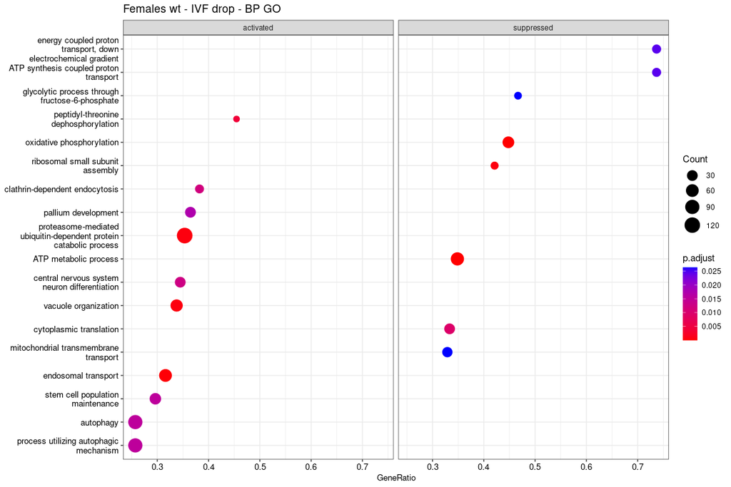

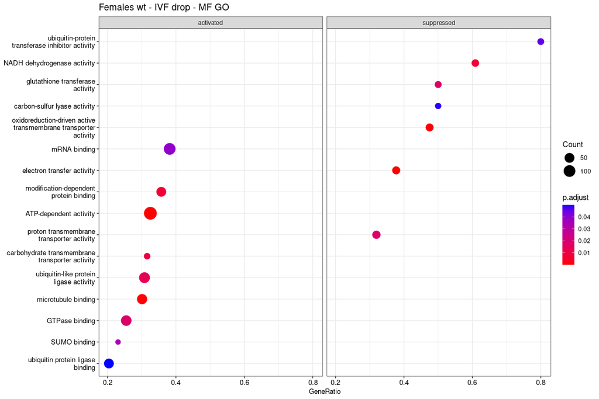

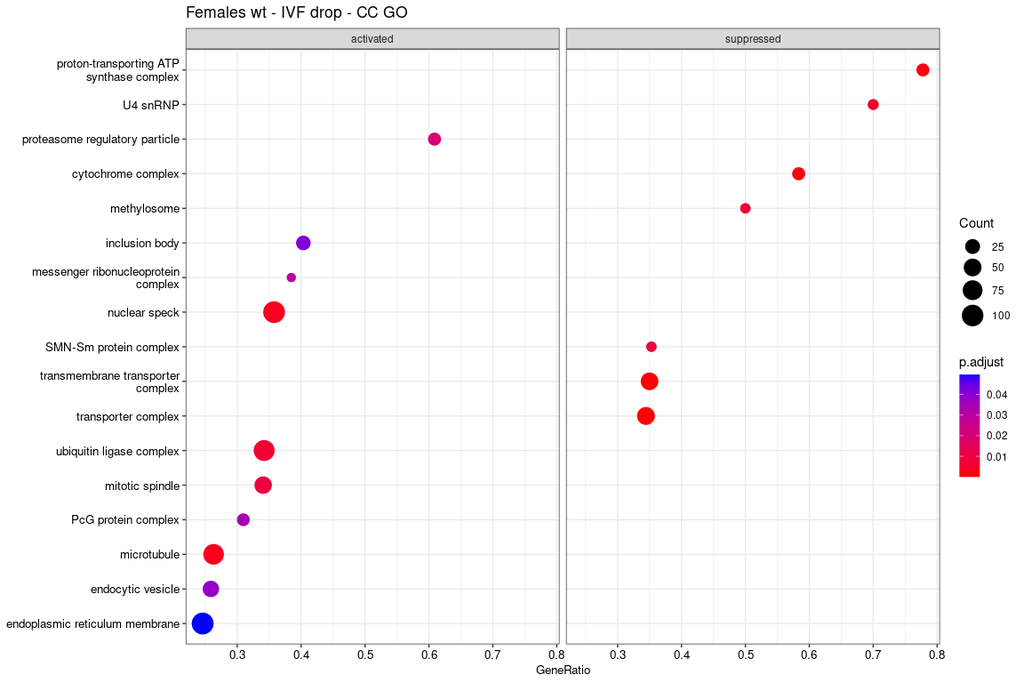

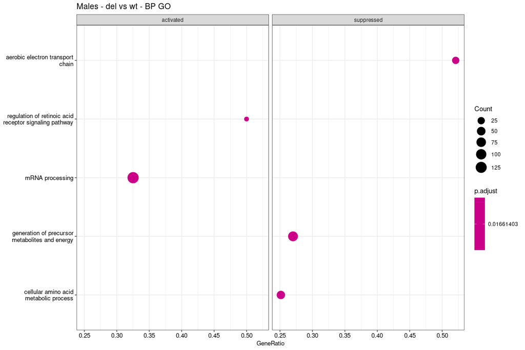

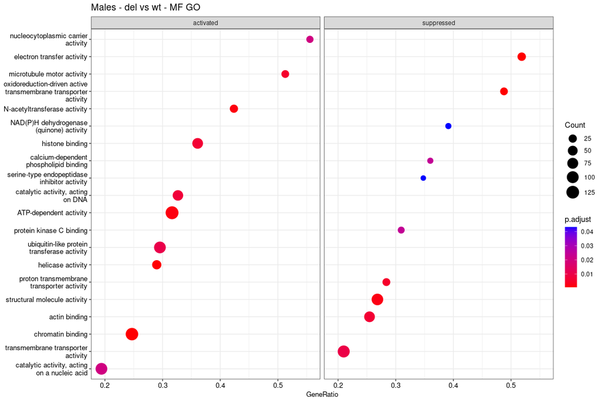

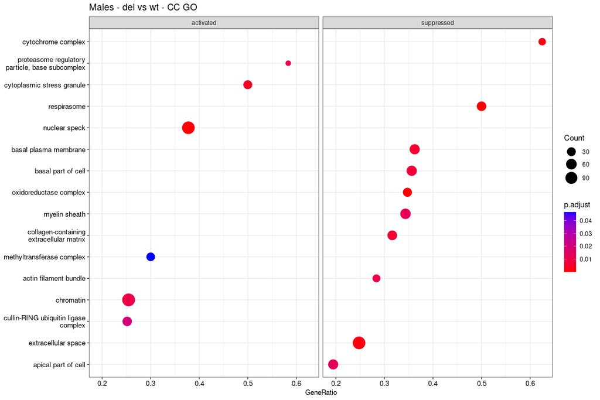

Many significantly enriched gene sets are shared by female blastocysts when comparing IVF drops. This is in agreement with what observed already with DEGs counts: there is an effect - either due to the mothers’ genotype or to the IVF drop (experimental batch effect) which acts on a fraction of the genes which are differentially expressed due to the mutation. In particular, these genes are downregulated/upregulated due to the mutation and also downregulated/upregulated when the mother is OgtT931A-het.

# 5 Combined GSEA result

I combine the GSEA results, then show the most significant terms for the male comparison.

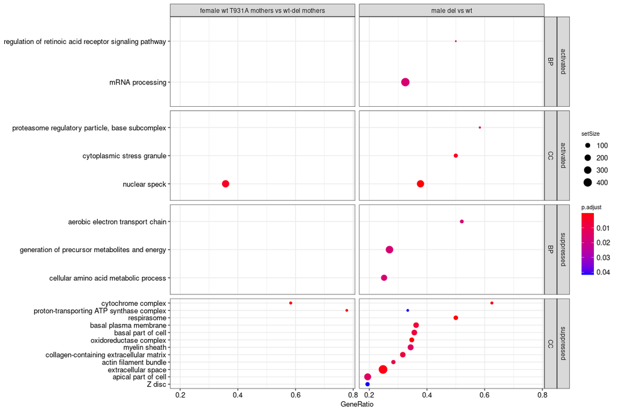